# Parkinson data - II

Giovanni Saraceno

```r
library(tidyverse)
library(dplyr)
library(ggplot2)
```

```r
dat <- read.csv('parkinsons_updrs.data', he = TRUE, sep = ',')
dat$subject. <- as.factor(dat$subject.)
dat$sex <- ifelse(dat$sex == 1, 'F', 'M')
dat$sex <- as.factor(dat$sex)
```

#### Multiple Linear Regression

In order to estimates the $\beta$’s parameters, the most famous method id the ordinary least squares (OLS). It is based on minimizing the sum of squared residuals.

It is common to assess the goodness-of-fit of the OLS regression by comparing how much the initial variation in the sample can be reduced by regressing onto X. The coefficient of determination $R^2$ is defined as a ratio of “explained” variance to the “total” variance of the dependent variable $y$, in the cases where the regression sum of squares equals the sum of squares of residuals
$$R^2 = \frac{\sum(\hat{y}_i - \bar{y})^2}{\sum(y_i
- \bar{y})^2} = 1 - \frac{RSS}{TSS}$$
where TSS is the total sum of squares for the dependent variable. In order for $R^2$ to be meaningful, the matrix $X$ of data on regressors must contain a column vector of ones to represent the constant whose coefficient is the regression intercept. In that case, $R^2$ will always be a number between 0 and 1, with values close to 1 indicating a good degree of fit.

Let’s see the application to the Parkinson data.

```r
mod1 <- lm(total_UPDRS ~ age + sex + test_time + Jitter... +
             Shimmer + NHR + HNR + RPDE + DFA + PPE,
           data = dat)
summary(mod1)
```

```
##
## Call:
## lm(formula = total_UPDRS ~ age + sex + test_time + Jitter... +
##     Shimmer + NHR + HNR + RPDE + DFA + PPE, data = dat)
##
## Residuals:
##     Min      1Q  Median      3Q     Max
## -27.970  -7.473  -1.578   7.343  26.858
##
## Coefficients:
##               Estimate Std. Error t value Pr(>|t|)
## (Intercept)  37.993036   3.090434  12.294  < 2e-16 ***
## age           0.309125   0.015065  20.520  < 2e-16 ***
## sexM          1.895360   0.293151   6.465 1.09e-10 ***
## test_time     0.015600   0.002397   6.508 8.27e-11 ***
## Jitter...   101.443427  50.074953   2.026   0.0428 *
## Shimmer     -42.262092  10.186302  -4.149 3.39e-05 ***
## NHR         -22.390765   5.137487  -4.358 1.33e-05 ***
## HNR          -0.587395   0.067702  -8.676  < 2e-16 ***
## RPDE          3.083135   1.754558   1.757   0.0789 .
## DFA         -33.414836   2.220918 -15.046  < 2e-16 ***
## PPE          12.193496   2.609037   4.674 3.03e-06 ***
## ---
## Signif. codes:  0 '***' 0.001 '**' 0.01 '*' 0.05 '.' 0.1 ' ' 1
##
## Residual standard error: 9.792 on 5864 degrees of freedom
## Multiple R-squared:  0.164,  Adjusted R-squared:  0.1626
## F-statistic:   115 on 10 and 5864 DF,  p-value: < 2.2e-16
```

The output of a linear model includes:

1. **Std. Error** is the standard deviation of the sampling distribution of the estimate of the coefficient under the standard regression assumptions. Such standard deviations are called standard errors of the corresponding quantity (the coefficient estimate in this case).
2. **t value** is the value of the t-statistic for testing whether the corresponding regression coefficient is different from 0.
3. **Pr.** is the p-value for the hypothesis test for which the t value is the test statistic. It tells you the probability of a test statistic at least as unusual as the one you obtained, if the null hypothesis were true. In this case, the null hypothesis is that the true coefficient is zero; if that probability is low, it’s suggesting that it would be rare to get a result as unusual as this if the coefficient were really zero.
4. The **Residual standard error** represents the standard deviation of the residuals. It’s a measure of how close the fit is to the points.
5. The **Multiple R-squared**, also called the coefficient of determination is the proportion of the variance in the data that’s explained by the model. The more variables you add - even if they don’t help - the larger this will be. The Adjusted one reduces that to account for the number of variables in the model.
6. The **F statistic** on the last line is telling you whether the regression as a whole is performing ‘better than random’ - any set of random predictors will have some relationship with the response, so it’s seeing whether your model fits better than you’d expect if all your predictors had no relationship with the response (beyond what would be explained by that randomness). This is used for a test of whether the model outperforms ‘noise’ as a predictor. The p-value in the last row is the p-value for that test, essentially comparing the full model you fitted with an intercept-only model.

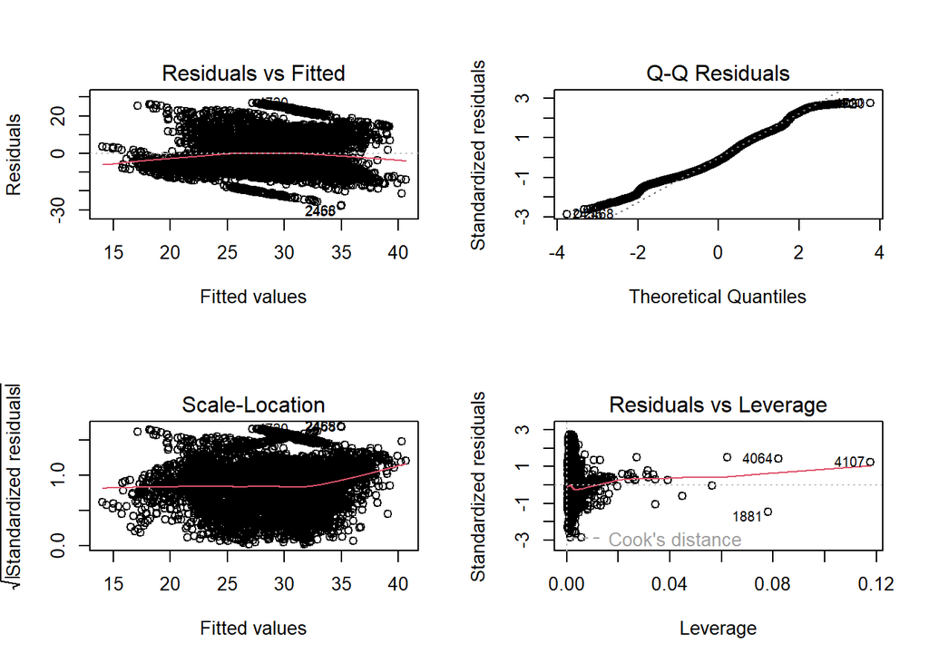

```r
par(mfrow = c(2, 2))
plot(mod1)
```

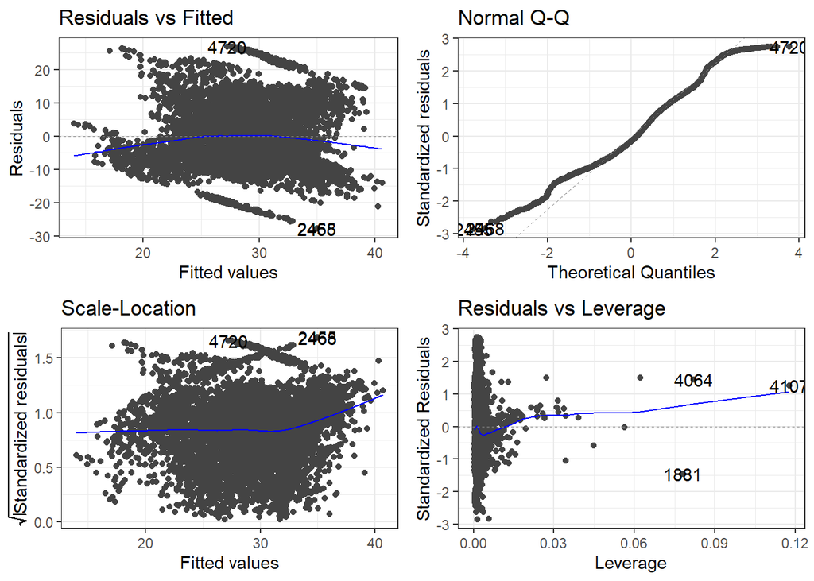

```r
library(ggfortify)
autoplot(mod1) +
  theme_bw()
```

We can also look how good are our fitted values:

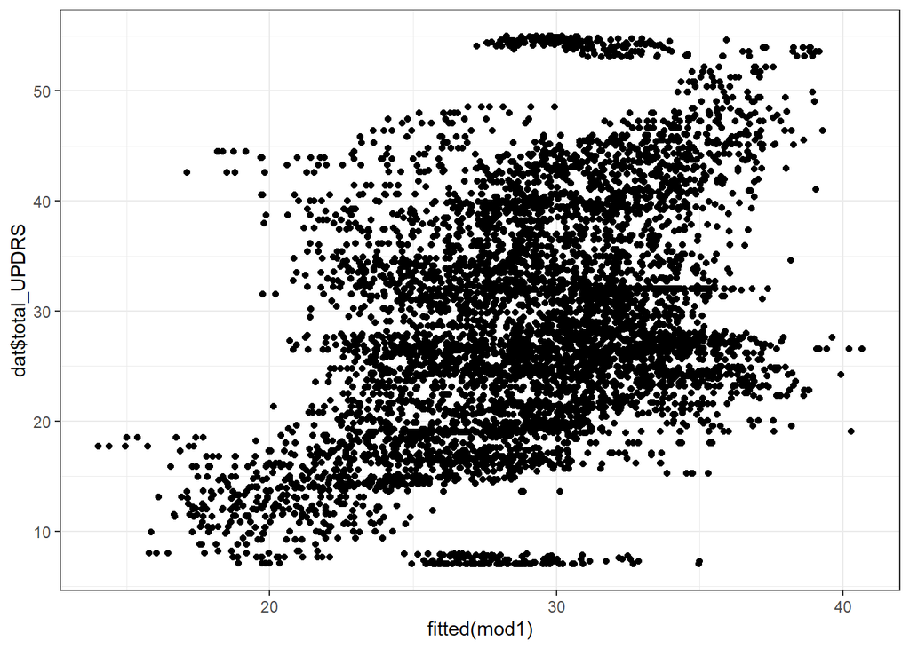

```r
ggplot() +
  geom_point(aes(x = fitted(mod1), y = dat$total_UPDRS)) +
  theme_bw()
```

It is clear that there is some peculiar behaviour. Let us try to underline the observations belonging to each subject

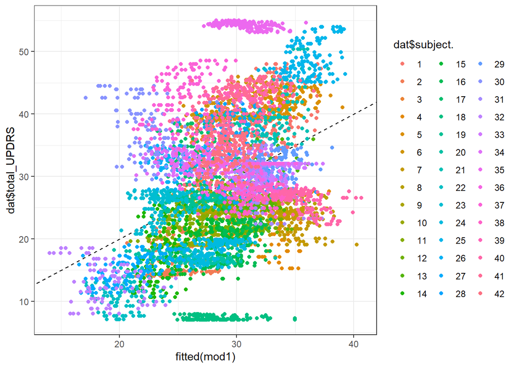

```r
ggplot() +
  geom_abline(linetype = 'dashed') +
  geom_point(aes(x = fitted(mod1), y = dat$total_UPDRS, col = dat$subject.)) +
  theme_bw()
```

It seems the response variable strongly depend on the subjects.

#### Assumptions

1. The errors in the regression should have conditional mean zero.
2. The regressors in $X$ must all be linearly independent. Usually, it is also assumed that the regressors have finite moments up to at least the second moment. When this assumption is violated the regressors are called linearly dependent or perfectly multicollinear. In such case the value of the regression coefficient $\beta$ cannot be learned.
3. Spherical errors, i.e. $Var[\epsilon|X] = \sigma^2 I_n$
4. Errors are normally distributed. i.e. $\epsilon|X \sim N(0, \sigma^2 I_n)$.

Let’s focus on the residuals, and try to underline the errors belonging to each subject.

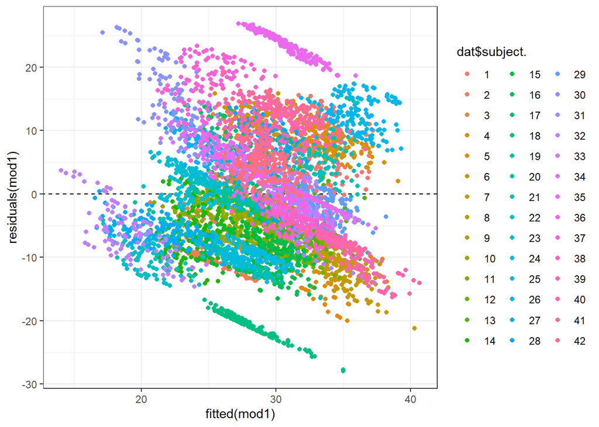

```r
ggplot() +
  geom_abline(intercept = 0, slope = 0, linetype = 'dashed') +
  geom_point(aes(x = fitted(mod1), y = residuals(mod1), col = dat$subject.)) +
  theme_bw()
```

We see that the residuals corresponding to the observations of a specific subject are grouped together. This is a particular case in which there is autocorrelation between residuals. In fact, since we have repeated measures for each subject, it is not strange to imagine that the errors belonging to a particular subject might be correlated. For instance, imagine each subject having a different instrument, each characterized by small measurement error. In this case, the observations repeated observations taken by the subjects would be independent from each other, but highly correlated within subject. Notice that the distribution of estimates is much more spread out, with the variance being higher, if correlated covariates are considered.

We can try to include the variable subject as a categorical variable

```r
mod2 <- lm(total_UPDRS ~ subject. + age + sex + test_time +
             Jitter... + Shimmer + NHR + HNR + RPDE +DFA + PPE,
           data = dat)
summary(mod2)
```

```
##
## Call:
## lm(formula = total_UPDRS ~ subject. + age + sex + test_time +
##     Jitter... + Shimmer + NHR + HNR + RPDE + DFA + PPE, data = dat)
##
## Residuals:
##     Min      1Q  Median      3Q     Max
## -10.764  -1.257   0.037   1.506   9.248
##
## Coefficients: (2 not defined because of singularities)
##               Estimate Std. Error  t value Pr(>|t|)
## (Intercept)  3.790e+01  1.097e+00   34.562  < 2e-16 ***
## subject.2   -2.417e+01  3.662e-01  -65.985  < 2e-16 ***
## subject.3   -7.340e+00  3.041e-01  -24.138  < 2e-16 ***
## subject.4   -1.682e+01  3.364e-01  -49.981  < 2e-16 ***
## subject.5    1.485e+00  3.148e-01    4.717 2.45e-06 ***
## subject.6    7.710e-01  3.125e-01    2.467  0.01364 *
## subject.7   -1.742e+01  3.060e-01  -56.920  < 2e-16 ***
## subject.8   -1.476e+01  3.136e-01  -47.056  < 2e-16 ***
## subject.9   -1.569e+01  3.620e-01  -43.345  < 2e-16 ***
## subject.10  -2.092e+01  3.153e-01  -66.352  < 2e-16 ***
## subject.11  -1.781e+01  3.160e-01  -56.357  < 2e-16 ***
## subject.12  -1.629e+01  3.372e-01  -48.301  < 2e-16 ***
## subject.13  -1.273e+01  3.307e-01  -38.499  < 2e-16 ***
## subject.14  -2.272e+01  3.200e-01  -71.009  < 2e-16 ***
## subject.15  -2.151e+01  3.146e-01  -68.374  < 2e-16 ***
## subject.16  -2.183e+01  3.428e-01  -63.677  < 2e-16 ***
## subject.17  -8.845e+00  3.129e-01  -28.267  < 2e-16 ***
## subject.18  -3.321e+01  3.245e-01 -102.339  < 2e-16 ***
## subject.19  -1.477e+01  3.531e-01  -41.829  < 2e-16 ***
## subject.20  -2.371e+01  3.774e-01  -62.834  < 2e-16 ***
## subject.21  -2.733e-01  3.375e-01   -0.810  0.41807
## subject.22  -2.994e+01  3.453e-01  -86.712  < 2e-16 ***
## subject.23  -1.521e+01  3.401e-01  -44.732  < 2e-16 ***
## subject.24  -2.204e+01  3.736e-01  -58.992  < 2e-16 ***
## subject.25   8.333e+00  3.164e-01   26.339  < 2e-16 ***
## subject.26  -9.101e+00  3.547e-01  -25.658  < 2e-16 ***
## subject.27  -2.538e+01  3.607e-01  -70.361  < 2e-16 ***
## subject.28  -5.586e+00  3.631e-01  -15.383  < 2e-16 ***
## subject.29  -9.504e+00  3.027e-01  -31.394  < 2e-16 ***
```

[output cut: 14 more lines]

```
## sexM                NA         NA       NA       NA
## test_time    1.872e-02  6.395e-04   29.270  < 2e-16 ***
## Jitter...    4.627e+01  1.485e+01    3.116  0.00184 **
## Shimmer      8.267e-01  3.059e+00    0.270  0.78698
## NHR         -3.741e+00  1.683e+00   -2.223  0.02623 *
## HNR          5.443e-02  2.304e-02    2.362  0.01820 *
## RPDE        -1.040e-01  5.742e-01   -0.181  0.85624
## DFA         -5.524e-01  1.093e+00   -0.505  0.61323
## PPE         -8.488e-02  8.135e-01   -0.104  0.91690
## ---
## Signif. codes:  0 '***' 0.001 '**' 0.01 '*' 0.05 '.' 0.1 ' ' 1
##
## Residual standard error: 2.581 on 5825 degrees of freedom
## Multiple R-squared:  0.9423, Adjusted R-squared:  0.9418
## F-statistic:  1941 on 49 and 5825 DF,  p-value: < 2.2e-16
```

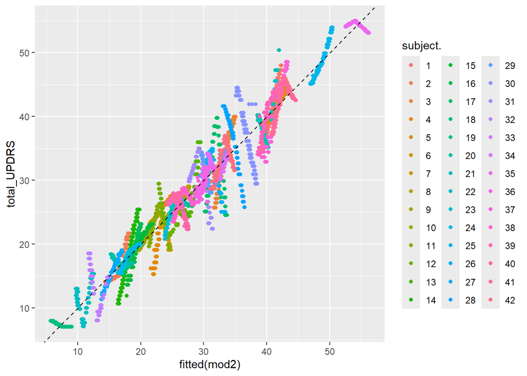

```r
ggplot(dat) +
  geom_point(aes(x = fitted(mod2), y = total_UPDRS, color=subject.)) +
  geom_abline(linetype = 'dashed')
```

Why R gives the warning (2 not defined because of singularities) and we have two coefficients estimated as NA?

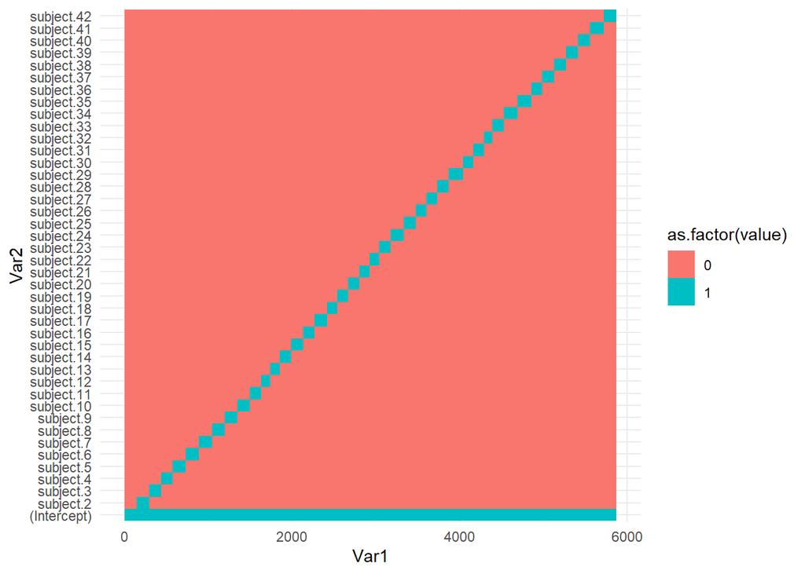

```r
library(reshape2)
mat <- model.matrix(~ 1 + subject., data = dat)
dat_mat <- melt(mat)
ggplot(dat_mat, aes(x = Var1, y = Var2, fill = as.factor(value))) +
  geom_tile() +
  theme_minimal()
```

It is useful to consider estimation techniques for linear regressions different from the classical least squares. One alternative id the *Iterative Reweighted Least Squares* (IRLS) which is commonly used for robust regression or for generalized linear models. The MASS package provides the `rlm` function for robust regression using IRLS.

```r
library(MASS)
model_irls <- rlm(total_UPDRS ~  age + sex + test_time +
             Jitter... + Shimmer + NHR + HNR + RPDE + DFA + PPE,
           data = dat)
summary(model_irls)
```

```
##
## Call: rlm(formula = total_UPDRS ~ age + sex + test_time + Jitter... +
##     Shimmer + NHR + HNR + RPDE + DFA + PPE, data = dat)
## Residuals:
##     Min      1Q  Median      3Q     Max
## -27.761  -7.179  -1.237   7.470  28.142
##
## Coefficients:
##             Value    Std. Error t value
## (Intercept)  38.3448   3.0577    12.5402
## age           0.3029   0.0149    20.3232
## sexM          1.8840   0.2900     6.4953
## test_time     0.0154   0.0024     6.4990
## Jitter...   152.8948  49.5453     3.0860
## Shimmer     -43.7958  10.0786    -4.3454
## NHR         -23.2111   5.0831    -4.5663
## HNR          -0.5296   0.0670    -7.9057
## RPDE          6.4223   1.7360     3.6995
## DFA         -38.4485   2.1974   -17.4971
## PPE          11.2060   2.5814     4.3410
##
## Residual standard error: 10.8 on 5864 degrees of freedom
```

Another method is the *Least Absolute Shrinkage and Selection Operator* (LASSO), which can be performed using the `glmnet` package.

```r
library(glmnet)
x_matrix <- as.matrix(dat[, c(2:4,7, 12, 18:22)])
# LASSO regression
model_lasso <- glmnet(x_matrix, dat$total_UPDRS, alpha = 1)

# Cross-validation for selecting lambda
cv_model <- cv.glmnet(x_matrix, dat$total_UPDRS, alpha = 1)

# Best lambda
best_lambda <- cv_model$lambda.min

# Model with the best lambda
model_lasso_best <- glmnet(x_matrix, dat$total_UPDRS, alpha = 1, lambda = best_lambda)
coef(model_lasso_best)
```

```
## 11 x 1 sparse Matrix of class "dgCMatrix"
##                       s0
## (Intercept)  35.87444701
## age           0.31019263
## sex           .
## test_time     0.01560369
## Jitter...   105.51655615
## Shimmer     -37.11045108
## NHR         -27.57307268
## HNR          -0.53970963
## RPDE          5.28699135
## DFA         -32.33834432
## PPE          13.91418118
```

The Bayesian information criterion (BIC) and Akaike information criterion (AIC) offer a framework of comparing fits of models with a different number of parameters.

```r
# AIC and BIC for LS
aic_ls <- AIC(mod1)
bic_ls <- BIC(mod1)

# AIC and BIC for IRLS
n <- length(dat$total_UPDRS)
logLik_irls <- sum(dnorm(model_irls$residuals, mean = 0, sd = sd(model_irls$residuals), log = TRUE))
aic_irls <- -2 * logLik_irls + 2 * length(coef(model_irls))
bic_irls <- -2 * logLik_irls + log(n) * length(coef(model_irls))

# AIC and BIC for LASSO
y <- dat$total_UPDRS
y_hat_lasso <- predict(model_lasso_best, s = best_lambda, newx = as.matrix(x_matrix))
rss_lasso <- sum((y - y_hat_lasso)^2)
sigma_hat_lasso <- sqrt(rss_lasso / n)
logLik_lasso <- -n / 2 * log(2 * pi * sigma_hat_lasso^2) - rss_lasso / (2 * sigma_hat_lasso^2)
aic_lasso <- -2 * logLik_lasso + 2 * sum(coef(model_lasso_best) != 0)
bic_lasso <- -2 * logLik_lasso + log(n) * sum(coef(model_lasso_best) != 0)

# Combine Results
comparison <- data.frame(
  Model = c("LS", "IRLS", "LASSO"),
  AIC = c(aic_ls, aic_irls, aic_lasso),
  BIC = c(bic_ls, bic_irls, bic_lasso)
)
print(comparison)
```

```
##   Model      AIC      BIC
## 1    LS 43493.74 43573.88
## 2  IRLS 43508.98 43582.44
## 3 LASSO 43531.50 43598.29
```

We finally construct a table comparing the obtained estimates

```r
coeff_ls <- coef(mod1)
coeff_irls <- coef(model_irls)
coeff_lasso <- coef(model_lasso_best)[-1]  # Remove intercept for comparison

# Combine Results
coefficients <- data.frame(
  Variable = c("(Intercept)", paste0("X", 1:10)),
  LS = coeff_ls,
  IRLS = coeff_irls,
  LASSO = c(as.numeric(coef(model_lasso_best)[1]), as.numeric(coeff_lasso)))

# View Results
print(coefficients)
```

```
##                Variable           LS         IRLS        LASSO
## (Intercept) (Intercept)  37.99303565  38.34480753  35.87444701
## age                  X1   0.30912518   0.30292540   0.31019263
## sexM                 X2   1.89536037   1.88397176   0.00000000
## test_time            X3   0.01560014   0.01541468   0.01560369
## Jitter...            X4 101.44342681 152.89484031 105.51655615
## Shimmer              X5 -42.26209151 -43.79583797 -37.11045108
## NHR                  X6 -22.39076525 -23.21113933 -27.57307268
## HNR                  X7  -0.58739500  -0.52957482  -0.53970963
## RPDE                 X8   3.08313516   6.42232561   5.28699135
## DFA                  X9 -33.41483563 -38.44852881 -32.33834432
## PPE                 X10  12.19349626  11.20598927  13.91418118
```

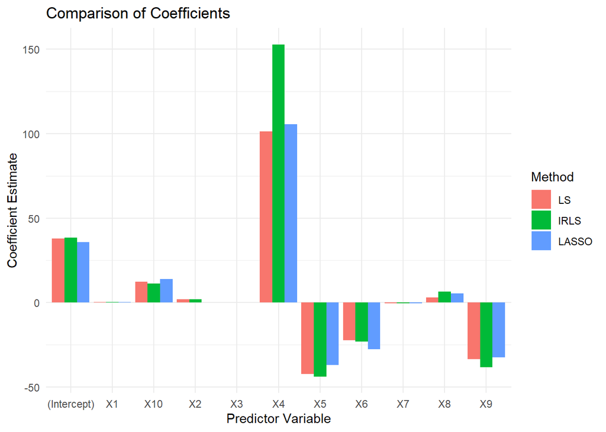

```r
# Plotting Coefficients for Comparison
library(reshape2)
coeff_melt <- melt(coefficients, id.vars = "Variable", variable.name = "Method", value.name = "Coefficient")

library(ggplot2)
ggplot(coeff_melt, aes(x = Variable, y = Coefficient, fill = Method)) +
  geom_bar(stat = "identity", position = "dodge") +
  theme_minimal() +
  labs(title = "Comparison of Coefficients", y = "Coefficient Estimate", x = "Predictor Variable")
```